# Exploratory Data Analysis of Starbucks’ and Dunkin Donuts’ Nutritional Information

Final Project  
Data Science 1 with R (STAT 301-1)

Author

Rohan Krishnamurthi

Published

December 8, 2023

**Github Repo Link**

https://github.com/stat301-1-2023-fall/final-project-1-rohankrishnamurthi2025

## Introduction

In this report, I am inquiring about the nutritional information of Starbucks’ and Dunkin Donuts’ food and drink items. The first dataset I am analyzing contains relevant nutritional information of all beverages available at Starbucks. The second dataset concerns all of the food items available at Starbucks. The third dataset concerns the nutritional information of all products, both food and drink items, available at Dunkin Donuts.

### Motivation for Research

I chose these datasets because I normally enjoy both Starbucks’s and Dunkin Donuts’ offerings. However, it must be noted that many students and I are currently boycotting Starbucks due to the company’s decision to not support for the Palestinian people given the humanitarian crisis they are currently experiencing. While I enjoy their products, I currently will not support the company due to this issue.

Nevertheless, I have had plenty of items from both their drink and food menus and I feel knowledgeable enough to work with data concerning both. Also, I really enjoy making and trying intricate coffee and tea drinks, so I’d be happy to work with data regarding Starbucks and Dunkin Donuts. I decided to include the food information as well as a challenge to work with multiple sets of data. Working with data from both Starbucks and Dunkin Donuts allows more depth in the exploration of nutrition information.

### Research Questions

The overarching research question for this EDA is what can one consume at either Starbucks or Dunkin Donuts in order to maintain a healthy, nutritious diet. There are many ways to address this question. Some initial querries are how do the calories, fat, protein and sugar vary by drink type or by food item at either retailer. To involve both food and drink items, I propose investigating which combination of food and drink items is most nutritious, at either Starbucks or Dunkin Donuts. A related question I have is which drink or food items are least nutritious and should be generally avoided. Lastly, I propose questioning how nutritious food and drinks vary from Starbucks and Dunkin Donuts, and which restaurant has the most nutritious options overall.

## Data Overview and Quality

The three raw datasets were then copied into new datasets, which were then cleaned and prepared for analysis. The first raw dataset, entitled “starbucks.csv”, contains 18 variables and 242 observations, corresponding to 242 different drinks. Three of the variables contain categorical data, corresponding to drink identifiers, and the remaining 15 variables contain numerical data, corresponding to nutritional information. There are some observations (specifically, caffeine) with missing nutritional values, which contain NA instead of the actual numerical values.

The second raw dataset, stored as “starbucks_menu_nutrition_food_redo.csv”, contains 6 variables and 113 observations, corresponding to 113 different food items. One variable contains categorical data, corresponding to the food name. The remaining five variables contain numerical data, corresponding to the nutritional information, such as calories, fat, carbohydrates, fiber, and protein content. There are no missing values in this data set.

### Raw dataset links:

– Starbucks drinks dataset:

https://github.com/reisanar/datasets/blob/master/starbucks.csv

– Starbucks food dataset:

https://www.kaggle.com/datasets/starbucks/starbucks-menu/

– Dunkin Donuts dataset:

https://www.kaggle.com/datasets/joebeachcapital/dunkin-donuts-nutrition

### Starbucks Data Cleaning and Preparation

In the `0a_starbucks_data_preparation` R script, the dataset “starbucks_menu_nutrition_food_redo.csv” was read in, copied as `starbucks_food_data`, and then cleaned. The first issue with the raw data was that the variable names had spaces, which could make it difficult ot select these variables. The spaces were replaced with underscores using the names() function. Also, the variable names were be made into lowercase names for consistency.

The dataset “starbucks.csv” was read in, copied as `starbucks_drinks_data`, and then cleaned as well. The data frame had the same issue in that the column names had uppercase letters and spaces. This was addressed using the names() function as well. Additionally, in the column names “Total Fat g”, “Dietary Fiber g”, and “Total Carbohydrates g”, the initial word was be removed so these variables would have identical names to the `starbucks_food_data` dataset. This made facilitated joining observations in both data frames.

In the `beverage_prep` column of `starbucks_drink_data`, the size of beverage was missing in some observations but could be deduced from the size listed of the previous (or second previous) beverage. The size was added to this column using a “for loop” to iterate through each observation and if statements to identify the size and then add it to the observation.

Additionally, the information in the `beverage_prep` column in `starbucks_drinks_data` was used to create new variables– one for milk type and one for size. First, the column `milk_type` was developed bt extracting the type of milk from the `beverage_prep` column. Drinks without any milk intentionally had `NA` in this column. A for loop was used to iterate through each observation in the `beverage_prep` column, and if statements were used to identify the type of milk and add it to the `milk_type` column for each observation. The column `size` was added by extracting the size of drink from the `beverage_prep` column. A for loop can was to iterate through each observation in the `beverage_prep` column, and if statements were used to identify the beverage size and add it to the `size` column for each observation.

Finally, a new data frame entitled `starbucks_all_data` was created by joining the two existing data frames with the merge() function. The `beverage` and `food_item` variables were renamed to `item`, so the data frames could share this variable. Then, the two data frames were combined by the variables `item`, `calories`, `fat_g`, `carb_g`, `fiber_g`, and `protein_g`, having selected these variables upon entering the data sets into the merge() function.

### Dunkin Donuts Data Cleaning and Preparation

In the `0b_dunkin_data_preparation` R script, the dataset “dunkindonutsnutrition.csv” was read in, copied as `dunkin_donuts_data`, and then cleaned. First, the variable named were changed with the names function to remove parentheses and spaces. Additionally, the names were made lowercase for consistency.

A new variable, `item_type` was created as a factor. The factor “drink” was assigned to drinks (based on the `category` variable) and the factor “food” was assigned to food items. Variables corresponding to nutritional information were converted into numeric vectors, as they generally contained numeric values. Moreover, a new factor variable, `size`, was created to identify the size of each product. The size was extracted from the `item` name using the grepl() function. Items that were not given a size or milk_type were assigned a factor of “not applicable”. Similarly, a new factor variable, `milk_type`, was created to identify the type of milk in each product, if applicable.

Finally, the data was filtered into two new datasets: `dunkin_donuts_drinks_data`, containing the drink observations; and `dunkin_donuts_food_data`, containing the food observations.

From the R scripts, the cleaned datasets were downloaded as csv files using the write_csv() function, and then they were accessed using the read_csv() function.

## Explorations

### Analysis of Drinks

#### Nutritional Content by Drink Category

##### Sugar, Fat, and Calories Content

The first question I sought to answer was which drinks are considered the healthiest. I initially approached this quesiton by comparing the fat, sugar, and calorie content of drinks. In these categories, a beverage with a lower amount of each of these nutrients is considered healthier. For this analysis, I compared drink categories, rather than the individual drinks themselves, as it made it easier to make generalizations about drinks.

The following table and three figures depict the fat, sugar, and calorie content of types of drinks sold by Starbucks.

Starbucks Drinks Nutritional Info

| Drink Category | Average fat content (g) | Average sugar content (g) | Average calories |
| --- | --- | --- | --- |
| Classic Espresso Drinks | 3 | 17 | 140 |
| Coffee | 0 | 0 | 4 |
| Frappuccino Blended Coffee | 3 | 57 | 277 |
| Frappuccino Blended Creme | 2 | 48 | 233 |
| Frappuccino Light Blended Coffee | 1 | 32 | 162 |
| Shaken Iced Beverages | 0 | 26 | 114 |
| Signature Espresso Drinks | 5 | 39 | 250 |
| Smoothies | 2 | 37 | 282 |
| Tazo Tea Drinks | 3 | 30 | 177 |

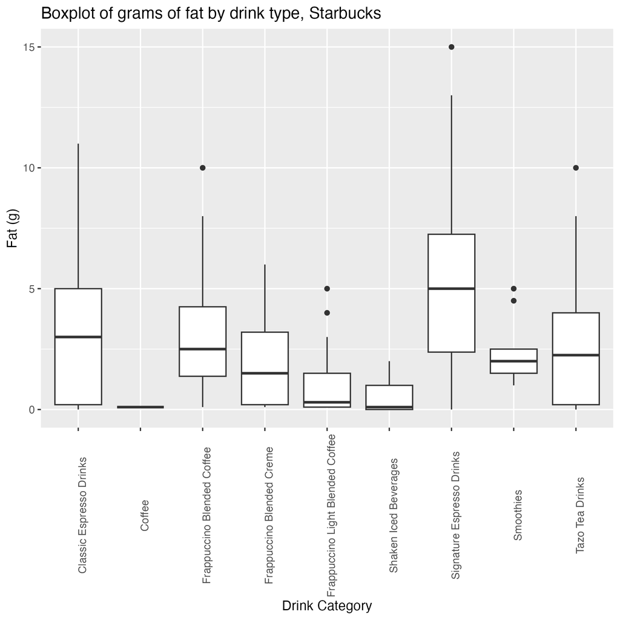

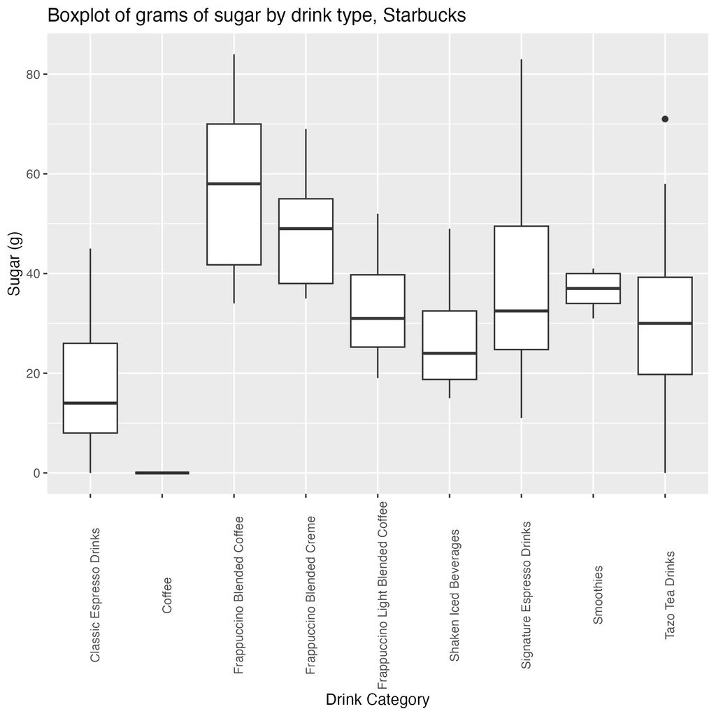

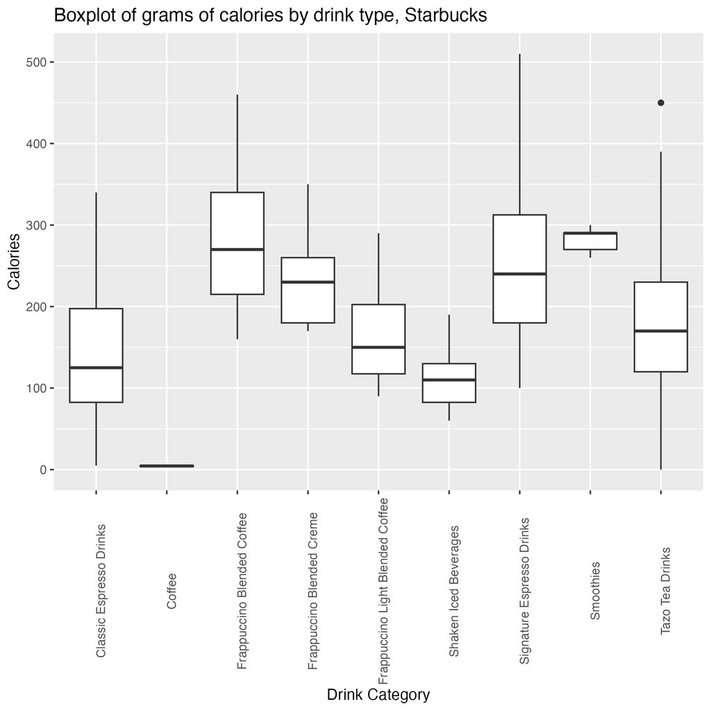

The following table and three figures depict the fat, sugar, and calorie content of types of drinks sold by Dunkin Donuts.

Dunkin Donuts Drinks Nutritional Info

| Drink Category | Average fat content (g) | Average sugar content (g) | Average calories |
| --- | --- | --- | --- |
| Cold Brew Coffee | 5 | 8 | 80 |
| Coolatta | 2 | 96 | 427 |
| Dunkin Refreshers | 5 | 60 | 320 |
| Frozen Coffee | 13 | 118 | 640 |
| Hot Americano | 0 | 0 | 8 |
| Hot Cappuccino | 3 | 39 | 223 |
| Hot Chocolate | 13 | 48 | 368 |
| Hot Coffee | 4 | 27 | 162 |
| Hot Latte | 6 | 43 | 274 |
| Hot Macchiato | 4 | 39 | 233 |
| Iced Americano | 0 | 0 | 8 |
| Iced Cappuccino | 3 | 39 | 223 |
| Iced Coffee | 3 | 24 | 142 |
| Iced Latte | 6 | 43 | 273 |
| Iced Macchiato | 3 | 39 | 226 |
| Iced Tea | 0 | 25 | 109 |

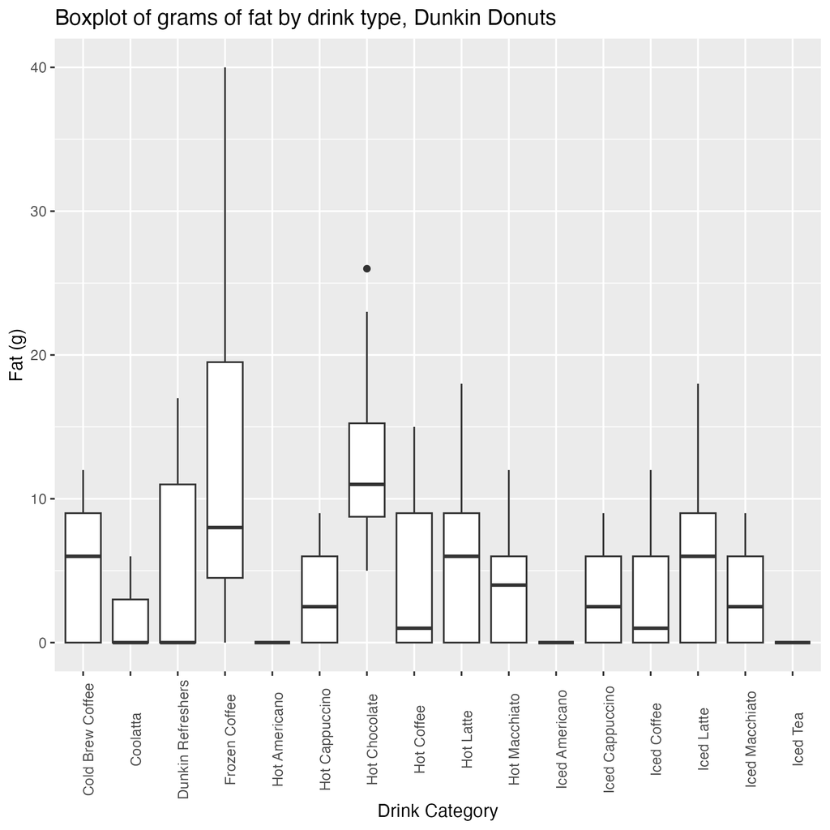

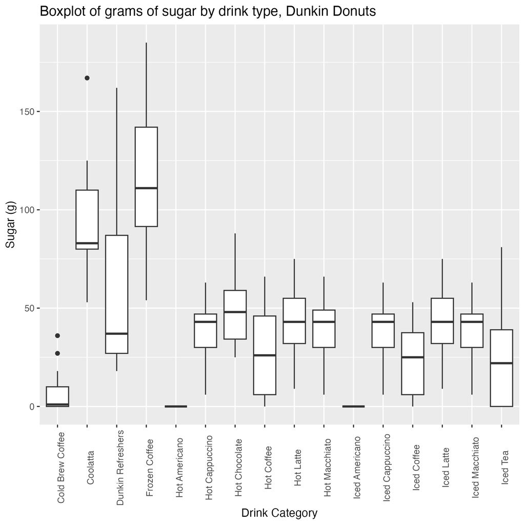

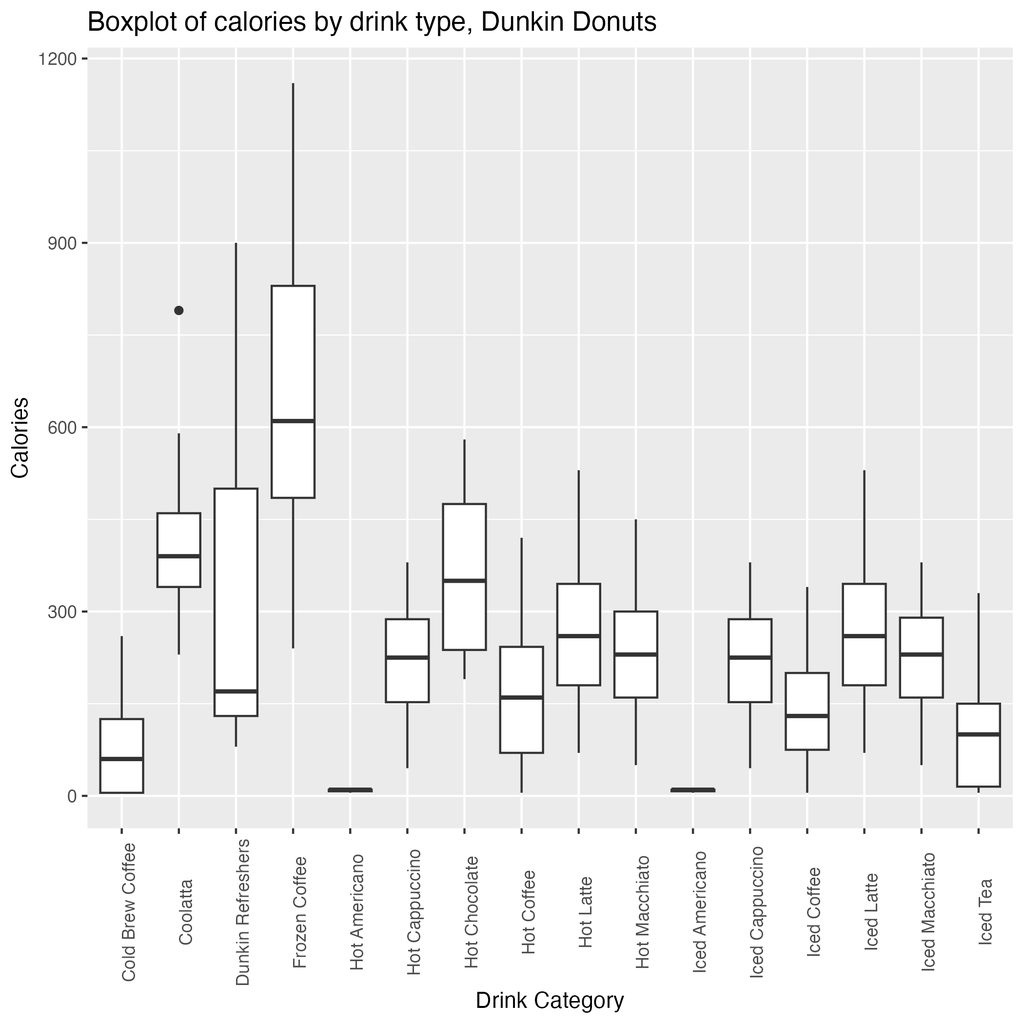

##### Protein, Calcium, and Vitamin A and C Content

I then address this questioned by investigating which beverages at each retailer had the highest amount of protein, calcium, and vitamins. In these categories, a beverage with a high content of each of these nutrients is considered more healthy.

Starbucks Drinks Nutritional Info, continued

| Drink Category | Average protein content (g) | Average calcium (%DV) | Average vitamin A (%DV) | Average vitamin C (%DV) |
| --- | --- | --- | --- | --- |
| Classic Espresso Drinks | 9 | 0 | 0 | 0 |
| Coffee | 1 | 0 | 0 | 0 |
| Frappuccino Blended Coffee | 4 | 0 | 0 | 0 |
| Frappuccino Blended Creme | 4 | 0 | 0 | 0 |
| Frappuccino Light Blended Coffee | 4 | 0 | 0 | 0 |
| Shaken Iced Beverages | 1 | 0 | 0 | 0 |
| Signature Espresso Drinks | 10 | 0 | 0 | 0 |
| Smoothies | 17 | 0 | 0 | 1 |
| Tazo Tea Drinks | 7 | 0 | 0 | 0 |

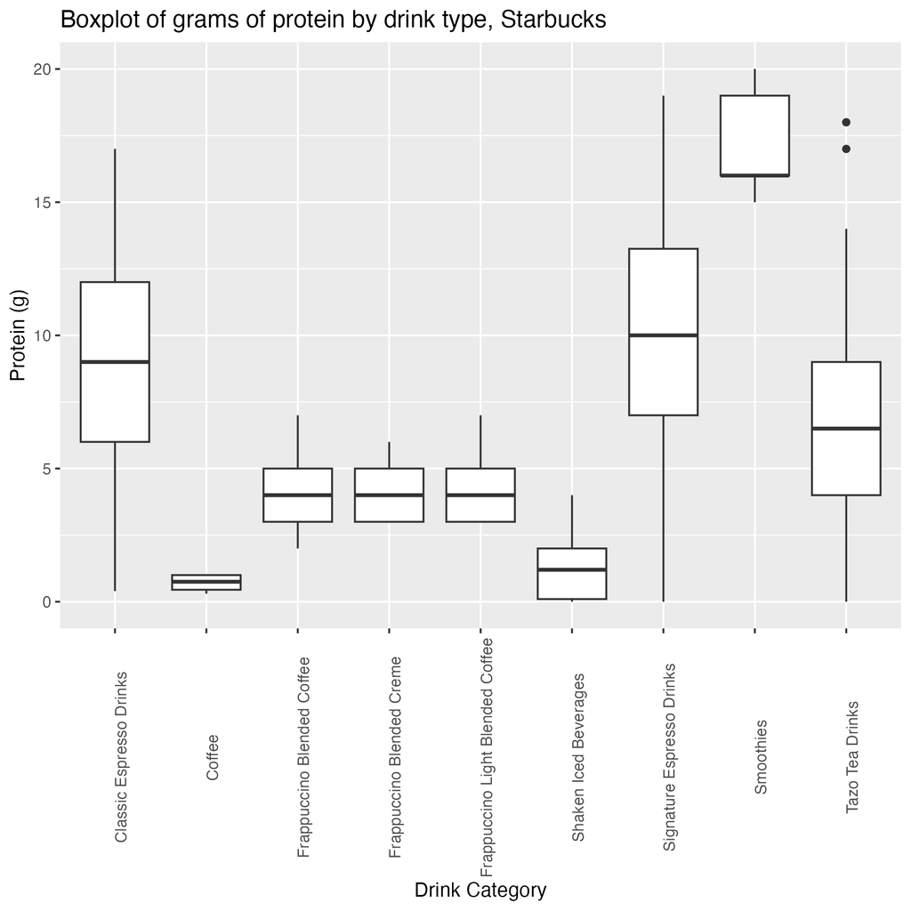

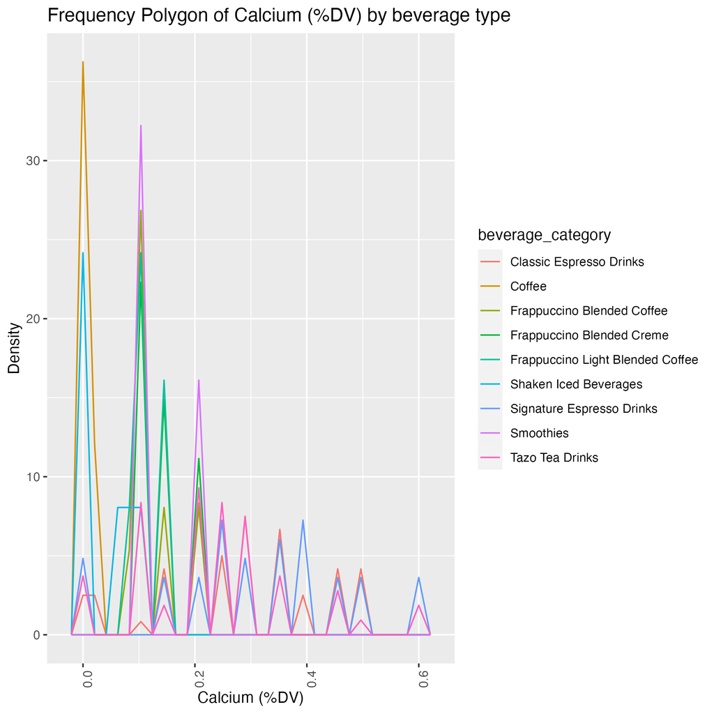

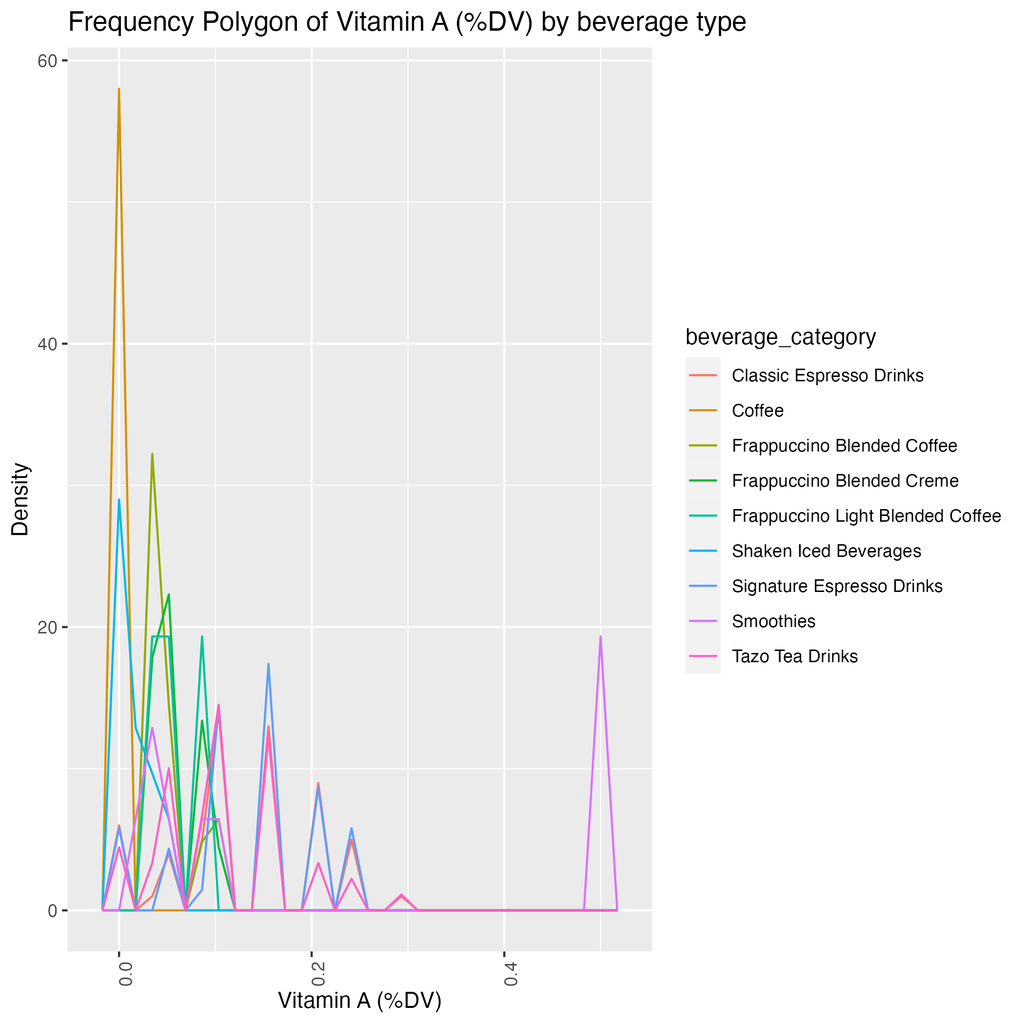

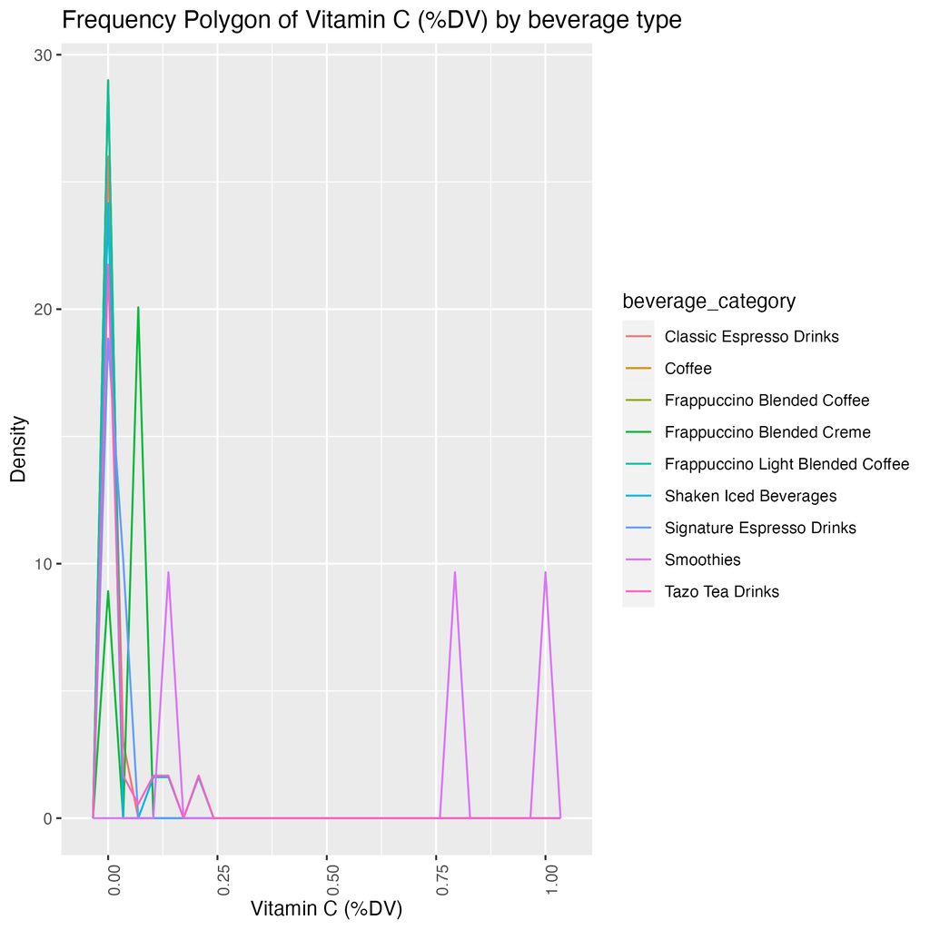

The Dunkin Donuts drinks data only contains information regarding each drink’s protein content. The protein content of each type of drink sold at Dunkin is compared in the following table and boxplot.

Dunkin Donuts Drinks Nutritional Info, continued

| Drink Category | Average protein content (g) |
| --- | --- |
| Cold Brew Coffee | 1 |
| Coolatta | 2 |
| Dunkin Refreshers | 3 |
| Frozen Coffee | 7 |
| Hot Americano | 0 |
| Hot Cappuccino | 7 |
| Hot Chocolate | 3 |
| Hot Coffee | 3 |
| Hot Latte | 10 |
| Hot Macchiato | 8 |
| Iced Americano | 0 |
| Iced Cappuccino | 7 |
| Iced Coffee | 3 |
| Iced Latte | 10 |
| Iced Macchiato | 7 |
| Iced Tea | 0 |

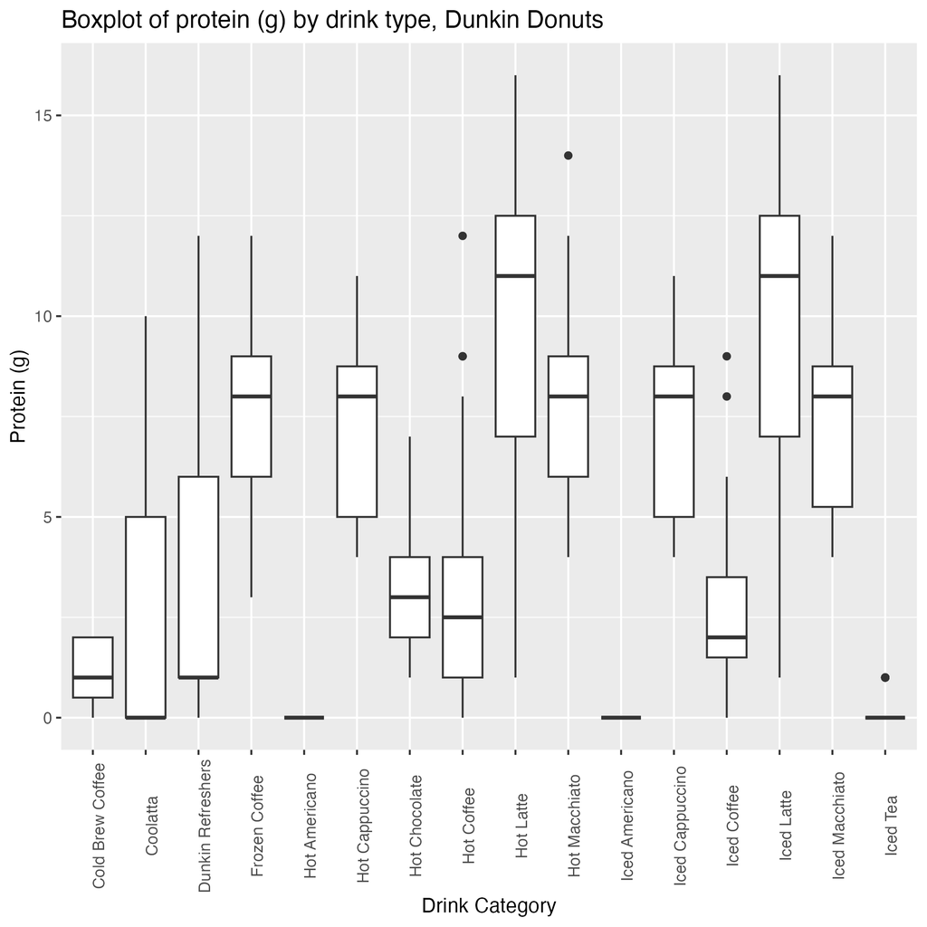

#### Nutritional Content by Milk Type

Another question I sought to answer is how the nutrition content of each drink varies by milk type. When people order drinks from coffee shops, there are many different ways they can customize their drink to their liking. Thus, I found it important to analyze nutrition by milk preference. For this analysis, I measured the fat, sugar, calories, and then protein of drinks having grouped them by milk type. This was done by creating boxplots, with `milk_type` being the categorical variable, and then `calories`, `fat_g`, `sugar_g` and then `protein_g` being the continuous variables.

The following graphs illustrate the average nutritional content of Starbucks drinks by type of milk.

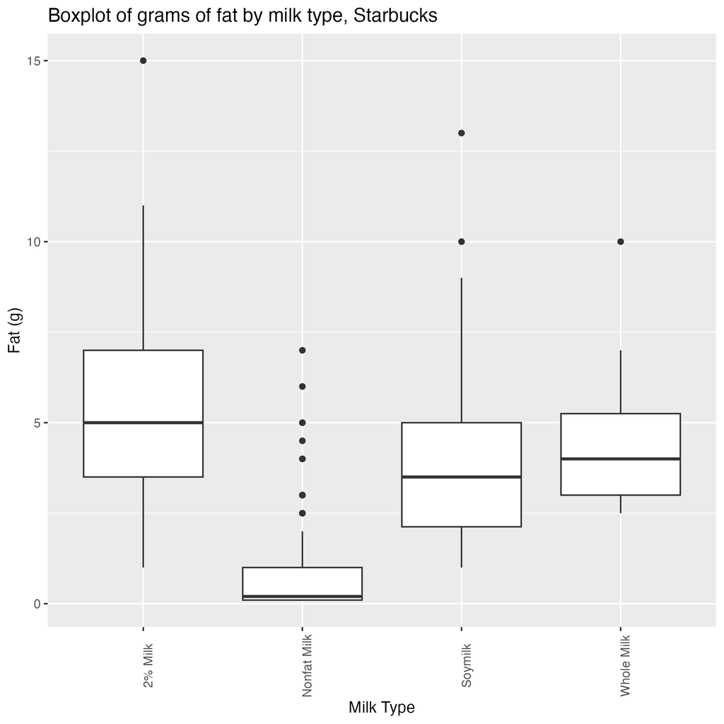

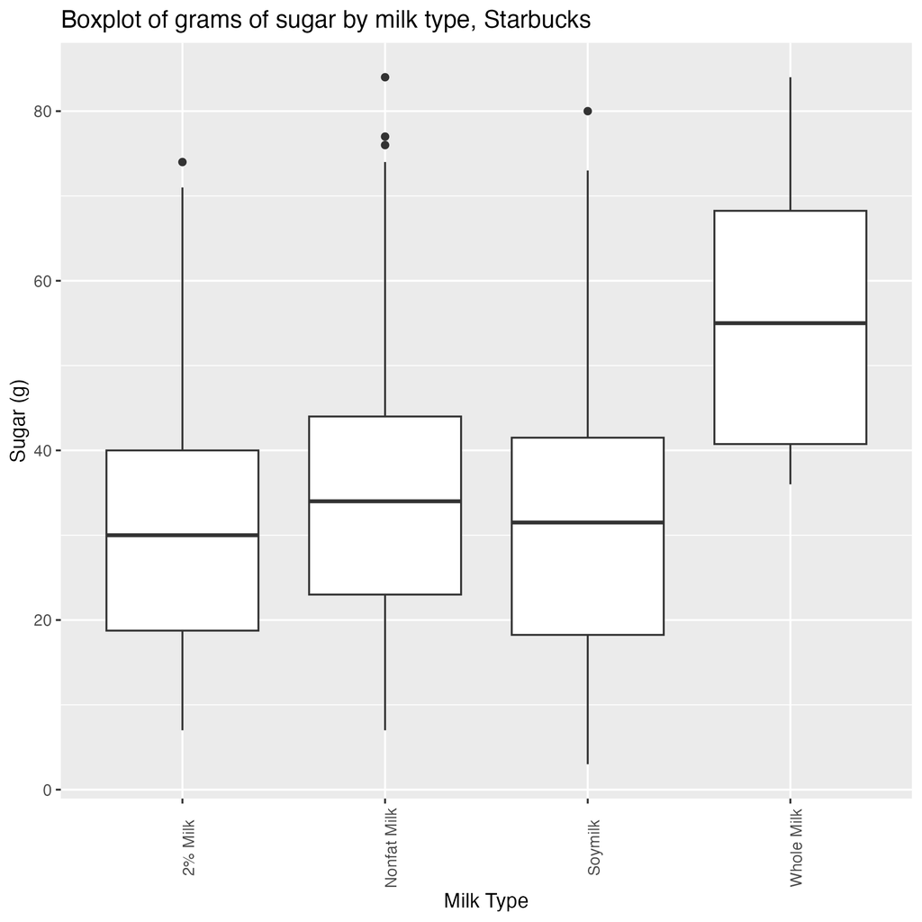

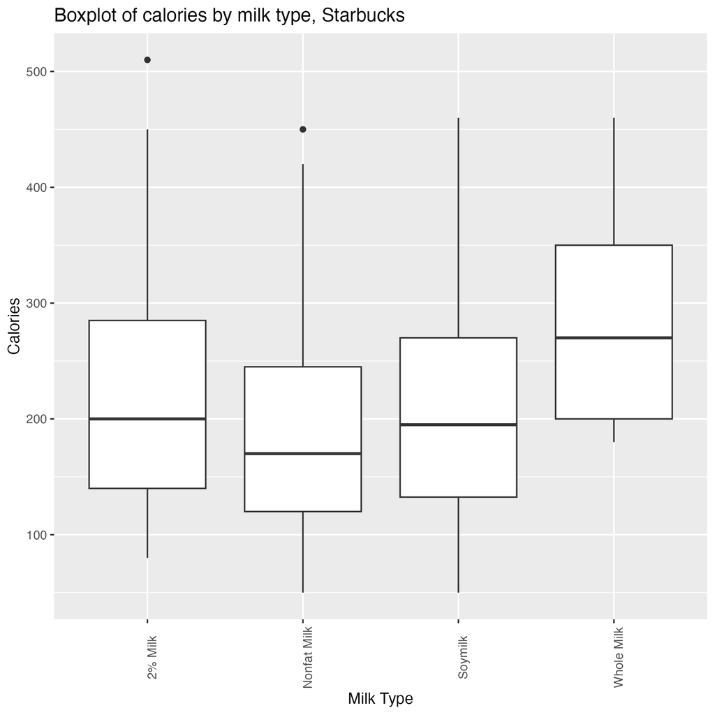

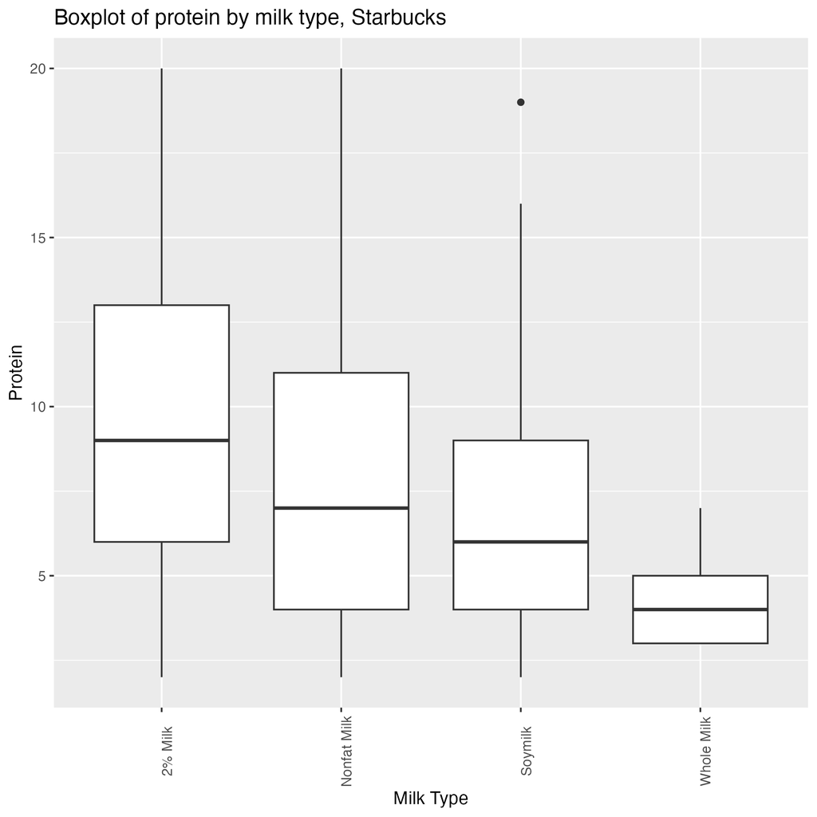

## References

Arvidsson, J. (2023, September) Dunkin’ Donuts’ Nutrition: Dunkin’ Donuts’ Menu Nutrition, Micronutrients, and Calorie Information. Kaggle. https://www.kaggle.com/datasets/joebeachcapital/dunkin-donuts-nutrition

Sanchez-Arias, R. (2023, October 19) Sample Datasets: A collection of datasets from multiple sources to be used for demonstrations in data science courses. GitHub. https://github.com/reisanar/datasets

Starbucks. (2017) Nutrition factors for Starbucks: Nutrition information for Starbucks menu items, including food and drinks. Kaggle. https://www.kaggle.com/datasets/starbucks/starbucks-menu/data